# Final report

Shanmukh Pinna

April 22, 2019

**Install libraries**

```r
library(readr) # to load the files
library(dplyr) # for data wrangling
library(stringr)# for string manipulation
library(zoo) # for filling missing values
library(corrplot)  # to access correlation functions
library(ggplot2) # for plotting
library(car) # heteroscedasticit test
library(tidyverse)  # data manipulation
library(cluster)    # clustering algorithms
library(factoextra) # clustering algorithms & visualization
```

**Gapminder dataset**

- Load gapminder data and assign to gap_d

```r
gap_d <- read.csv("https://raw.githubusercontent.com/shapinna/Final_Report/master/data/gapminder.csv", header=TRUE)

gap<-gap_d # New data frame gap is created

#head(gap)
```

# About gapminder dataset

```r
str(gap) # structure of gap data set
```

```
## 'data.frame':    41284 obs. of  6 variables:
##  $ Country   : Factor w/ 197 levels "Ã…land","Afghanistan",..: 2 2 2 2 2 2 2 2 2 2 ...
##  $ Year      : int  1800 1801 1802 1803 1804 1805 1806 1807 1808 1809 ...
##  $ life      : num  28.2 28.2 28.2 28.2 28.2 ...
##  $ population: Factor w/ 15260 levels "","1,005,328,574",..: 7490 1 1 1 1 1 1 1 1 1 ...
##  $ income    : int  603 603 603 603 603 603 603 603 603 603 ...
##  $ region    : Factor w/ 6 levels "America","East Asia & Pacific",..: 5 5 5 5 5 5 5 5 5 5 ...
```

```r
summary(gap) # summary of gap dataset
```

```
##                 Country           Year           life
##  Afghanistan        :  216   Min.   :1800   Min.   : 1.00
##  Albania            :  216   1st Qu.:1854   1st Qu.:31.00
##  Algeria            :  216   Median :1908   Median :35.12
##  Angola             :  216   Mean   :1907   Mean   :42.88
##  Antigua and Barbuda:  216   3rd Qu.:1962   3rd Qu.:55.60
##  Argentina          :  216   Max.   :2015   Max.   :84.10
##  (Other)            :39988
##    population        income                              region
##         :25817   Min.   :   142   America                   : 7961
##  121000 :    6   1st Qu.:   883   East Asia & Pacific       : 6256
##  14092  :    6   Median :  1450   Europe & Central Asia     :10468
##  1432000:    6   Mean   :  4571   Middle East & North Africa: 4309
##  229000 :    6   3rd Qu.:  3483   South Asia                : 1728
##  2574000:    6   Max.   :182668   Sub-Saharan Africa        :10562
##  (Other):15437   NA's   :2341
```

- 41284 observations with 6 columns
- Data set is covering 197 countries across 6 regions
- On an average there are 216 records for each country across multiple years
- Data is from year 1800 to 2015
- Country, region and population are with data type factor
- Year & income are with data type integer
- life is a numeric data type
- Income has 2341 null values
- No of records for each region
- America region has 7961 records
- East Asia & Pacific has 6256 records
- Europe & Central Asia has 10468 records
- Middle East & North Africa has 4309 records
- Sub-Saharan Africa has 10562 records
- South Asia has 1728 records

# Questions

- Which region is better in Life expectancy and Income before 1950 & after 1950?
- Whether life expectancy increased based on Income?
- Whether life expectancy improved over the years?
- Whether Income levels improved over the years?

# Data Wrangling

### Data Transformation

Converting Population data set from factor to Numeric for performing stastical analysis

- replacing comma

```r
gap$population <- lapply(gap$population, gsub, pattern = ",", replacement = "", fixed = TRUE)
```

- converting population column from factor to numeric

```r
# converting population column from factor to numeric
gap$population <- as.numeric(as.character(gap$population))
```

- verify class of population column

```r
class(gap$population)
```

```
## [1] "numeric"
```

### Verify records with null values

- Verify which columns has null values

```r
colSums(is.na(gap)) # verify number of null values column wise
```

```
##    Country       Year       life population     income     region
##          0          0          0      25817       2341          0
```

### Derive missing population numbers

- As population census is taken once in 10 years same value to be considered for next 9 years

```r
# replacing the null population value in the data frame with previous year not null value

gap$population <-na.locf(gap$population, fromLast = FALSE)

colSums(is.na(gap)) # verify number of null values column wise
```

```
##    Country       Year       life population     income     region
##          0          0          0          0       2341          0
```

- verify null value records

```r
 gap_null <-gap %>%
  filter_all(any_vars(is.na(.))) %>%
  group_by(Country,region)%>%
  summarise(count_na=sum(is.na(income)))

#gap_null

#sum(gap_null$count_na)
```

```r
gap_m<-gap[is.na(gap$income),]# subset of data with missing income fields


# Data of non missing values for the countries with missing values
 gap %>%
  filter(Country%in%gap_m$Country)%>%
  group_by(Country,region)%>%
  summarise(count_na=sum(!is.na(income))) %>%
  filter(count_na>0)
```

| Country | region | count_na |
| --- | --- | --- |
| Croatia | Europe & Central Asia | 196 |

From the above analysis we can conclude all the countries with missing income data dont have single record with income details except for croatia

- Croatia has values for 196 records and only 20 records has missing income

```r
# Analyze the income data for Croatia
#gap[gap$Country=="Croatia",]
```

- Croatia Income data has been collected only from 1820 and prior years is not collected hence it is not logical to populate missing income values of earlier years with mean or median.
- we conclude that missing income values to the extent of 2341 needs to be omitted on need bases based on the analysis.

# Exploratory Data Analysis

### Box plots and Variance analysis

#### Variance of life across regions

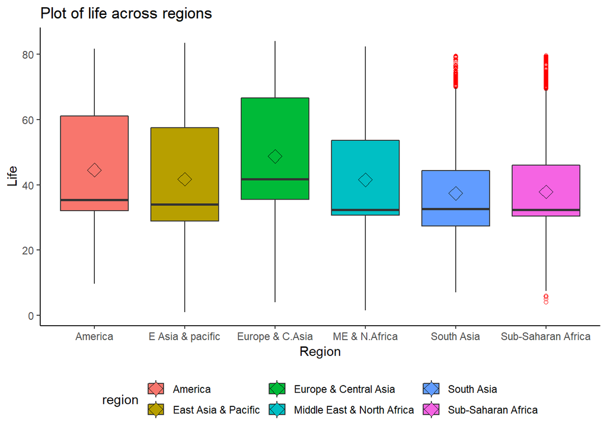

```r
ggplot(data=gap,mapping=aes(x=region,y=life,fill=region))+
 geom_boxplot(outlier.colour = "red", outlier.shape = 1)+
 # geom_boxplot(varwidth=TRUE)+
 theme_classic()+
 labs(title="Plot of life across regions",x="Region", y = "Life")+
  stat_summary(fun.y=mean, geom="point", shape=23, size=4)+
 theme(legend.position="bottom")+
  scale_x_discrete(labels=c("Europe & Central Asia" = "Europe & C.Asia", "Middle East & North Africa" = "ME & N.Africa",
                              "East Asia & Pacific" = "E Asia & pacific"))
```

```r
   # coord_flip()

gap %>%
  group_by(region) %>%
  summarize(mean_life=round(mean(life)), median_life=round(median(life)),
            sd_life = round(sd(life)),
            IQR_life = round(IQR(life)),
            mad_life = round(mad(life)))%>%
  arrange(desc(mean_life))
```

| region | mean_life | median_life | sd_life | IQR_life | mad_life |
| --- | --- | --- | --- | --- | --- |
| Europe & Central Asia | 49 | 42 | 17 | 31 | 15 |
| America | 45 | 35 | 17 | 29 | 9 |
| East Asia & Pacific | 42 | 34 | 17 | 29 | 12 |
| Middle East & North Africa | 42 | 32 | 17 | 23 | 4 |
| Sub-Saharan Africa | 38 | 32 | 12 | 16 | 4 |
| South Asia | 37 | 33 | 14 | 17 | 10 |

- Europe and Central Asia has high mean life of 49
- south asia and Sub-saharan Africa has comparable mean_life of 37 & 38.
- south asia has outliers near life 80 and sub-saharan has outlier at high and low life.

##### Variance of life across regions before 1950

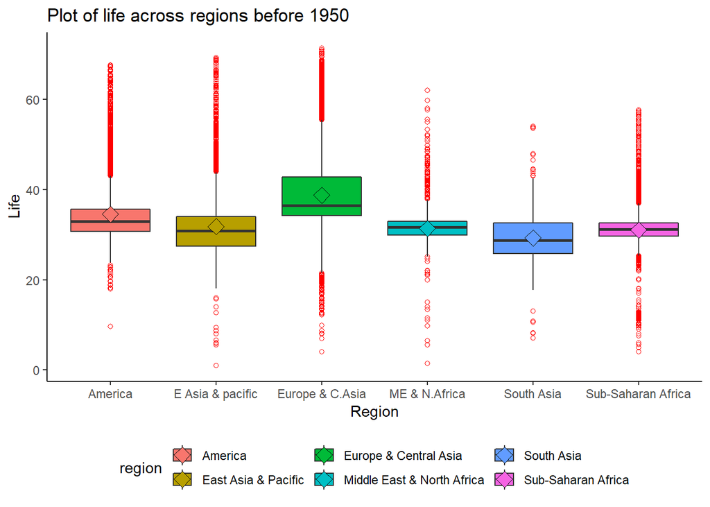

```r
ggplot(data=gap[gap$Year<1950,],mapping=aes(x=region,y=life,fill=region))+
 geom_boxplot(outlier.colour = "red", outlier.shape = 1)+
 # geom_boxplot(varwidth=TRUE)+
 theme_classic()+
 labs(title="Plot of life across regions before 1950",x="Region", y = "Life")+
  stat_summary(fun.y=mean, geom="point", shape=23, size=4)+
 theme(legend.position="bottom")+
  scale_x_discrete(labels=c("Europe & Central Asia" = "Europe & C.Asia", "Middle East & North Africa" = "ME & N.Africa",
                              "East Asia & Pacific" = "E Asia & pacific"))
```

```r
 # scale_x_discrete(limits=c("Europe & Central Asisa","America","Sub-Saharan Africa"))+
   # coord_flip()

#gap[gap$Year>1950,]
```

```r
gap %>%
  filter(Year<1950) %>%
  group_by(region) %>%
  summarize(mean_life=round(mean(life)), median_life=round(median(life)),
            sd_life = round(sd(life)),
            IQR_life = round(IQR(life)),
            mad_life = round(mad(life)))%>%
  arrange(desc(mean_life))
```

| region | mean_life | median_life | sd_life | IQR_life | mad_life |
| --- | --- | --- | --- | --- | --- |
| Europe & Central Asia | 39 | 37 | 9 | 8 | 5 |
| America | 35 | 33 | 7 | 5 | 4 |
| East Asia & Pacific | 32 | 31 | 7 | 7 | 5 |
| Middle East & North Africa | 31 | 32 | 4 | 3 | 2 |
| Sub-Saharan Africa | 31 | 31 | 4 | 3 | 2 |
| South Asia | 29 | 29 | 5 | 7 | 6 |

- Before 1950 has large outliers in the data set for all the regions
- Europe & central asia is better with higher mean and median of 39 & 37 in life however, standard deviation is high out of all regions
- South asia was not doing well in life with mean & median of 29 and stand deviation of 5

##### Variance of life across regions after 1950

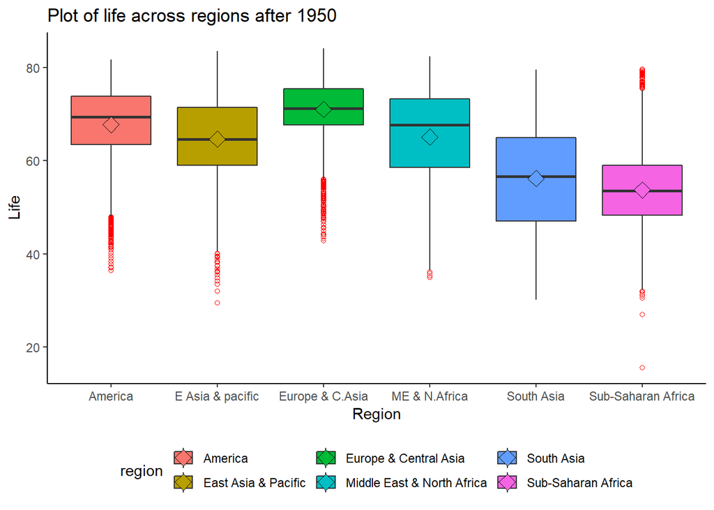

```r
ggplot(data=gap[gap$Year>1950,],mapping=aes(x=region,y=life,fill=region))+
 geom_boxplot(outlier.colour = "red", outlier.shape = 1)+
 # geom_boxplot(varwidth=TRUE)+
 theme_classic()+
 labs(title="Plot of life across regions after 1950",x="Region", y = "Life")+
  stat_summary(fun.y=mean, geom="point", shape=23, size=4)+
 theme(legend.position="bottom")+
  scale_x_discrete(labels=c("Europe & Central Asia" = "Europe & C.Asia", "Middle East & North Africa" = "ME & N.Africa",
                              "East Asia & Pacific" = "E Asia & pacific"))
```

```r
 # scale_x_discrete(limits=c("Europe & Central Asisa","America","Sub-Saharan Africa"))+
   # coord_flip()
```

```r
gap %>%
  filter(Year>1950) %>%
  group_by(region) %>%
  summarize(mean_life=round(mean(life)), median_life=round(median(life)),
            sd_life = round(sd(life)),
            IQR_life = round(IQR(life)),
            mad_life = round(mad(life)))%>%
  arrange(desc(mean_life))
```

| region | mean_life | median_life | sd_life | IQR_life | mad_life |
| --- | --- | --- | --- | --- | --- |
| Europe & Central Asia | 71 | 71 | 6 | 8 | 6 |
| America | 68 | 69 | 8 | 10 | 7 |
| East Asia & Pacific | 65 | 65 | 10 | 12 | 9 |
| Middle East & North Africa | 65 | 68 | 10 | 15 | 10 |
| South Asia | 56 | 57 | 11 | 18 | 13 |
| Sub-Saharan Africa | 54 | 54 | 8 | 11 | 8 |

- Life expectancy almost doubled before 1950 & after 1950 across all the regions
- Europe & central asia is doing better with mean and median life of 71 with lower standard deviation of 6
- South Asia improved more compared to sub-saharan africa
- Sub-Saharan africa is poor performer in life with mean and median of 54 and with standard deviation of 8 compared to other regions.

#### Variance of income across regions

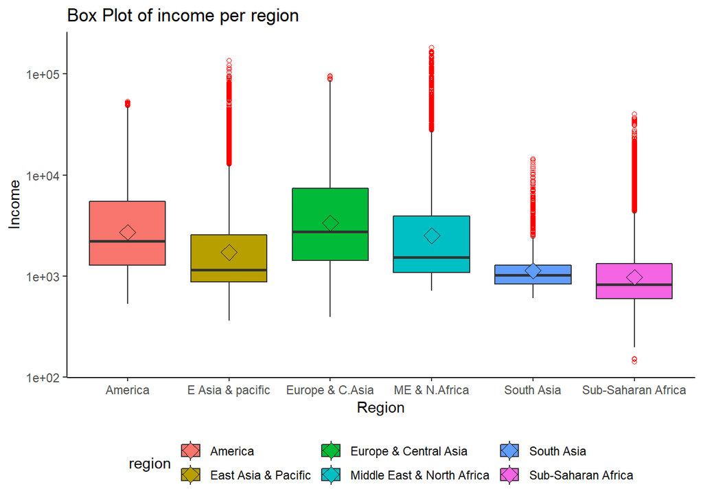

```r
ggplot(data=gap,mapping=aes(x=region,y=income,fill=region))+
 geom_boxplot(outlier.colour = "red", outlier.shape = 1,na.rm = TRUE)+
 theme_classic()+
 scale_y_continuous(trans='log10')+
 labs(title="Box Plot of income per region",x="Region", y = "Income")+
  stat_summary(fun.y=mean, geom="point", shape=23, size=4,na.rm = TRUE)+
  scale_x_discrete(labels=c("Europe & Central Asia" = "Europe & C.Asia", "Middle East & North Africa" = "ME & N.Africa",
                              "East Asia & Pacific" = "E Asia & pacific"))+
    theme(legend.position="bottom")
```

```r
gap[complete.cases(gap), ] %>%
  group_by(region) %>%
  summarize(mean_income=round(mean(income)), median_income=round(median(income)),
            sd_income = round(sd(income)),
            IQR_income = round(IQR(income)),
            mad_income = round(mad(income)))%>%
  arrange(desc(mean_income))
```

| region | mean_income | median_income | sd_income | IQR_income | mad_income |
| --- | --- | --- | --- | --- | --- |
| Middle East & North Africa | 8064 | 1538 | 20413 | 2854 | 923 |
| Europe & Central Asia | 6829 | 2735 | 10039 | 5960 | 2512 |
| America | 4595 | 2214 | 6151 | 4184 | 1774 |
| East Asia & Pacific | 4412 | 1154 | 10884 | 1684 | 732 |
| Sub-Saharan Africa | 1464 | 827 | 2458 | 727 | 434 |
| South Asia | 1385 | 1020 | 1394 | 446 | 274 |

##### Variance of income across regions before 1950

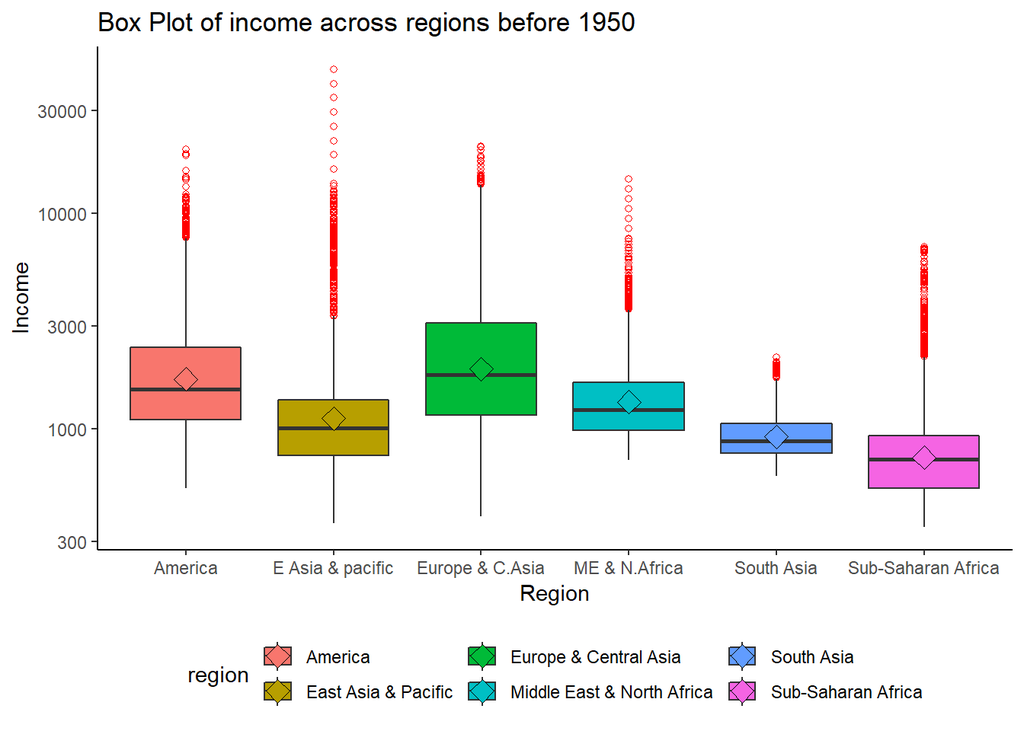

```r
ggplot(data=gap[gap$Year<1950,],mapping=aes(x=region,y=income,fill=region))+
 geom_boxplot(outlier.colour = "red", outlier.shape = 1,na.rm = TRUE)+
 theme_classic()+
 scale_y_continuous(trans='log10')+
 labs(title="Box Plot of income across regions before 1950",x="Region", y = "Income")+
  stat_summary(fun.y=mean, geom="point", shape=23, size=4,na.rm = TRUE)+
  scale_x_discrete(labels=c("Europe & Central Asia" = "Europe & C.Asia", "Middle East & North Africa" = "ME & N.Africa",
                              "East Asia & Pacific" = "E Asia & pacific"))+
    theme(legend.position="bottom")
```

```r
gap[complete.cases(gap), ] %>%
  filter(Year<1950) %>%
  group_by(region) %>%
  summarize(mean_income=round(mean(income)), median_income=round(median(income)),
            sd_income = round(sd(income)),
            IQR_income = round(IQR(income)),
            mad_income = round(mad(income)))%>%
  arrange(desc(mean_income))
```

| region | mean_income | median_income | sd_income | IQR_income | mad_income |
| --- | --- | --- | --- | --- | --- |
| Europe & Central Asia | 2473 | 1782 | 2103 | 1938 | 1234 |
| America | 2109 | 1520 | 1758 | 1292 | 807 |
| East Asia & Pacific | 1505 | 1006 | 2080 | 611 | 443 |
| Middle East & North Africa | 1480 | 1223 | 908 | 659 | 425 |
| South Asia | 955 | 878 | 285 | 288 | 235 |
| Sub-Saharan Africa | 832 | 719 | 577 | 399 | 285 |

- Before 1950 Income has high outlier across all regions
- Europe & Central Asia is better high mean & median income with high standard deviation
- sub saharan africa is poor peformer in income before 1950 with low mean and median income

##### Variance of income across regions after 1950

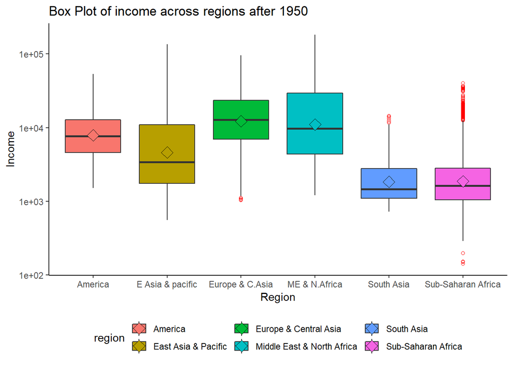

```r
ggplot(data=gap[gap$Year>1950,],mapping=aes(x=region,y=income,fill=region))+
 geom_boxplot(outlier.colour = "red", outlier.shape = 1,na.rm = TRUE)+
 theme_classic()+
 scale_y_continuous(trans='log10')+
 labs(title="Box Plot of income across regions after 1950",x="Region", y = "Income")+
  stat_summary(fun.y=mean, geom="point", shape=23, size=4,na.rm = TRUE)+
  scale_x_discrete(labels=c("Europe & Central Asia" = "Europe & C.Asia", "Middle East & North Africa" = "ME & N.Africa",
                              "East Asia & Pacific" = "E Asia & pacific"))+
    theme(legend.position="bottom")
```

```r
gap[complete.cases(gap), ] %>%
  filter(Year>1950) %>%
  group_by(region) %>%
  summarize(mean_income=round(mean(income)), median_income=round(median(income)),
            sd_income = round(sd(income)),
            IQR_income = round(IQR(income)),
            mad_income = round(mad(income)))%>%
  arrange(desc(mean_income))
```

| region | mean_income | median_income | sd_income | IQR_income | mad_income |
| --- | --- | --- | --- | --- | --- |
| Middle East & North Africa | 23326 | 9691 | 32402 | 25173 | 9468 |
| Europe & Central Asia | 16754 | 12767 | 13405 | 16436 | 10561 |
| East Asia & Pacific | 11021 | 3423 | 17764 | 9246 | 3025 |
| America | 10260 | 7624 | 8445 | 8154 | 5242 |
| Sub-Saharan Africa | 2922 | 1625 | 4029 | 1776 | 1087 |
| South Asia | 2382 | 1470 | 2203 | 1678 | 681 |

#### Variance of population across regions

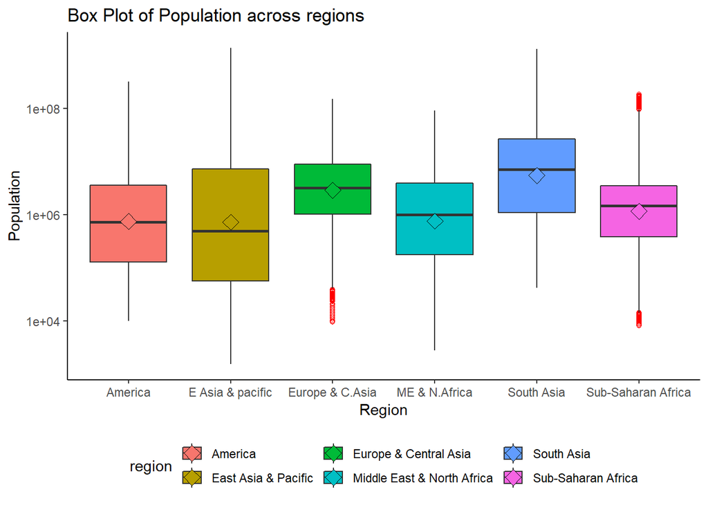

```r
ggplot(data=gap,mapping=aes(x=region,y=population,fill=region))+
 geom_boxplot(outlier.colour = "red", outlier.shape = 1,na.rm = TRUE)+
 theme_classic()+
 scale_y_continuous(trans='log10')+
 labs(title="Box Plot of Population across regions",x="Region", y = "Population")+
  stat_summary(fun.y=mean, geom="point", shape=23, size=4,na.rm = TRUE)+
  scale_x_discrete(labels=c("Europe & Central Asia" = "Europe & C.Asia", "Middle East & North Africa" = "ME & N.Africa",
                              "East Asia & Pacific" = "E Asia & pacific"))+
    theme(legend.position="bottom")
```

```r
gap[complete.cases(gap), ] %>%
  group_by(region) %>%
  summarize(mean_population=round(mean(population)), median_population=round(median(population)),
            sd_population = round(sd(population)),
            IQR_population = round(IQR(population)),
            mad_population = round(mad(population)))%>%
  arrange(desc(mean_population))
```

| region | mean_population | median_population | sd_population | IQR_population | mad_population |
| --- | --- | --- | --- | --- | --- |
| South Asia | 62951574 | 7034081 | 166919360 | 25441265 | 10317375 |
| East Asia & Pacific | 32226644 | 760947 | 128534787 | 10105071 | 1100340 |
| Europe & Central Asia | 9983582 | 3226542 | 18067980 | 7875726 | 3900148 |
| America | 8554762 | 943260 | 29789904 | 3733014 | 1300033 |
| Middle East & North Africa | 4690503 | 1126869 | 10262236 | 3995723 | 1575114 |
| Sub-Saharan Africa | 4396643 | 1567028 | 10624830 | 3234707 | 1861314 |

- South Asia and East asia & Pacific has more mean population with higher standard deviation and IQR compared to other regions
- Europe and central Asia has outliers for few countries for few year has lower population
- Sub Saharan Africa has outlier for few records for low and high population

##### Variance of population across regions before 1950

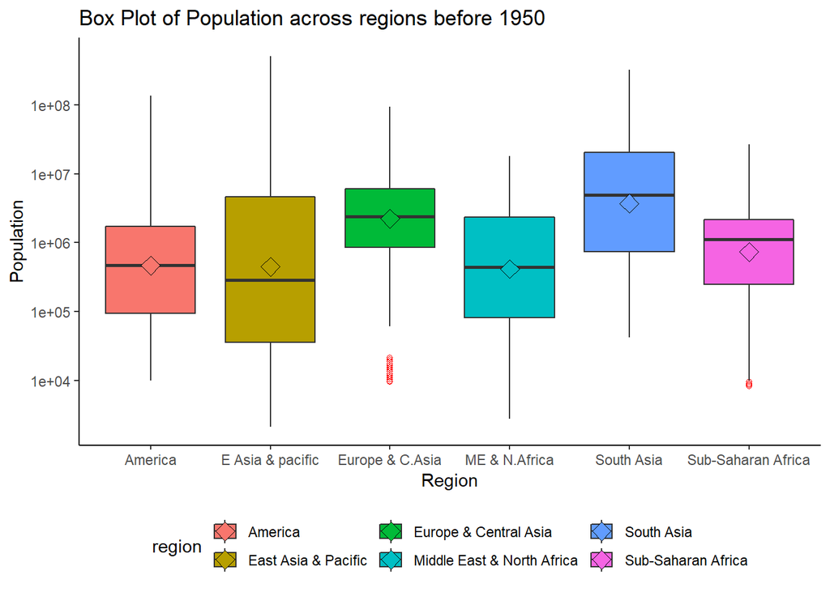

```r
ggplot(data=gap[gap$Year<1950,],mapping=aes(x=region,y=population,fill=region))+
 geom_boxplot(outlier.colour = "red", outlier.shape = 1,na.rm = TRUE)+
 theme_classic()+
 scale_y_continuous(trans='log10')+
 labs(title="Box Plot of Population across regions before 1950",x="Region", y = "Population")+
  stat_summary(fun.y=mean, geom="point", shape=23, size=4,na.rm = TRUE)+
  scale_x_discrete(labels=c("Europe & Central Asia" = "Europe & C.Asia", "Middle East & North Africa" = "ME & N.Africa",
                              "East Asia & Pacific" = "E Asia & pacific"))+
    theme(legend.position="bottom")
```

```r
gap[complete.cases(gap), ] %>%
  filter(Year<1950) %>%
  group_by(region) %>%
  summarize(mean_population=round(mean(population)), median_population=round(median(population)),
            sd_population = round(sd(population)),
            IQR_population = round(IQR(population)),
            mad_population = round(mad(population)))%>%
  arrange(desc(mean_population))
```

| region | mean_population | median_population | sd_population | IQR_population | mad_population |
| --- | --- | --- | --- | --- | --- |
| South Asia | 34828899 | 4878634 | 73122918 | 19358904 | 7110676 |
| East Asia & Pacific | 20569309 | 555887 | 77540176 | 5622920 | 795141 |
| Europe & Central Asia | 7362409 | 2420272 | 12796437 | 5245150 | 2832384 |
| America | 3473310 | 573924 | 12436302 | 1609159 | 778020 |
| Sub-Saharan Africa | 1924015 | 1199729 | 2831328 | 1907739 | 1360306 |
| Middle East & North Africa | 1914360 | 531472 | 2959336 | 2397946 | 728430 |

##### Variance of population across regions after 1950

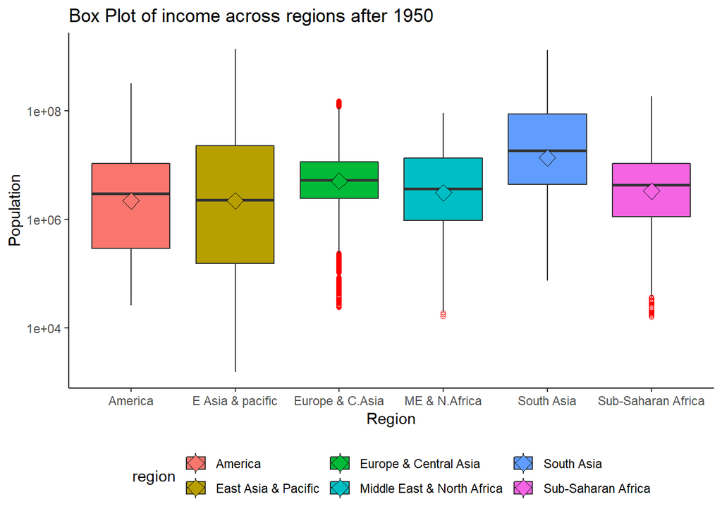

```r
ggplot(data=gap[gap$Year>1950,],mapping=aes(x=region,y=population,fill=region))+
 geom_boxplot(outlier.colour = "red", outlier.shape = 1,na.rm = TRUE)+
 theme_classic()+
 scale_y_continuous(trans='log10')+
 labs(title="Box Plot of income across regions after 1950",x="Region", y = "Population")+
  stat_summary(fun.y=mean, geom="point", shape=23, size=4,na.rm = TRUE)+
  scale_x_discrete(labels=c("Europe & Central Asia" = "Europe & C.Asia", "Middle East & North Africa" = "ME & N.Africa",
                              "East Asia & Pacific" = "E Asia & pacific"))+
    theme(legend.position="bottom")
```

```r
gap[complete.cases(gap), ] %>%
  filter(Year>1950) %>%
  group_by(region) %>%
  summarize(mean_population=round(mean(population)), median_population=round(median(population)),
            sd_population = round(sd(population)),
            IQR_population = round(IQR(population)),
            mad_population = round(mad(population)))%>%
  arrange(desc(mean_population))
```

| region | mean_population | median_population | sd_population | IQR_population | mad_population |
| --- | --- | --- | --- | --- | --- |
| South Asia | 127902534 | 18266934 | 272176871 | 80670492 | 26679171 |
| East Asia & Pacific | 58766181 | 3129612 | 198798115 | 25746428 | 4541840 |
| America | 20117297 | 3748738 | 48666932 | 12333584 | 5262008 |
| Europe & Central Asia | 15914925 | 5401951 | 25394330 | 10017096 | 5868168 |
| Middle East & North Africa | 11106234 | 3959988 | 16444490 | 13190670 | 5083425 |
| Sub-Saharan Africa | 10110198 | 4512795 | 17588533 | 9685666 | 5517276 |

### Correlation between elements of dataset

```r
# subset only numeric data type columns without missing values

gap_num <- gap[complete.cases(gap),c(3,4,5)] # removing missing records and only numeric columns

cor(gap_num)
```

```
##                life population     income
## life       1.000000 0.11850499 0.57640902
## population 0.118505 1.00000000 0.03431359
## income     0.576409 0.03431359 1.00000000
```

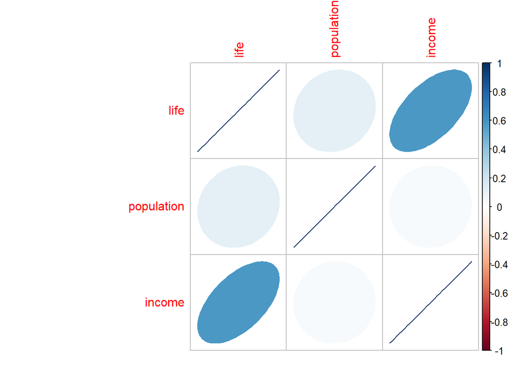

```r
corrplot(cor(gap_num),method="ellipse")
```

### Scatter plot to view correlation results

#### Income Vs Life

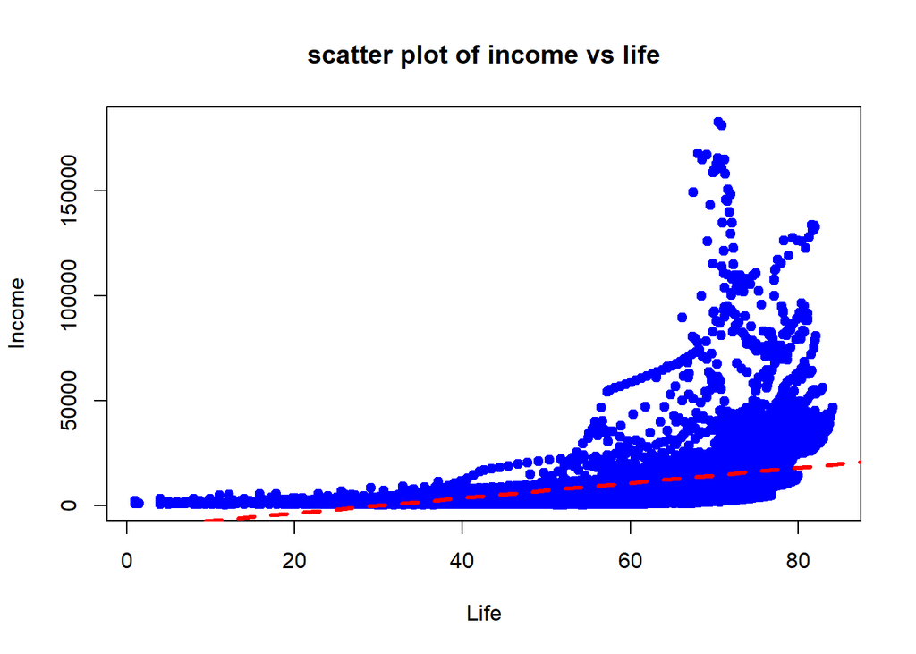

```r
plot(gap$income~gap$life,pch=19,col="blue",
     main='scatter plot of income vs life',
     xlab="Life",
     ylab='Income')
abline(lm(gap$income~gap$life),col="red",lty=2,lwd=3)
```

#### Population Vs Life

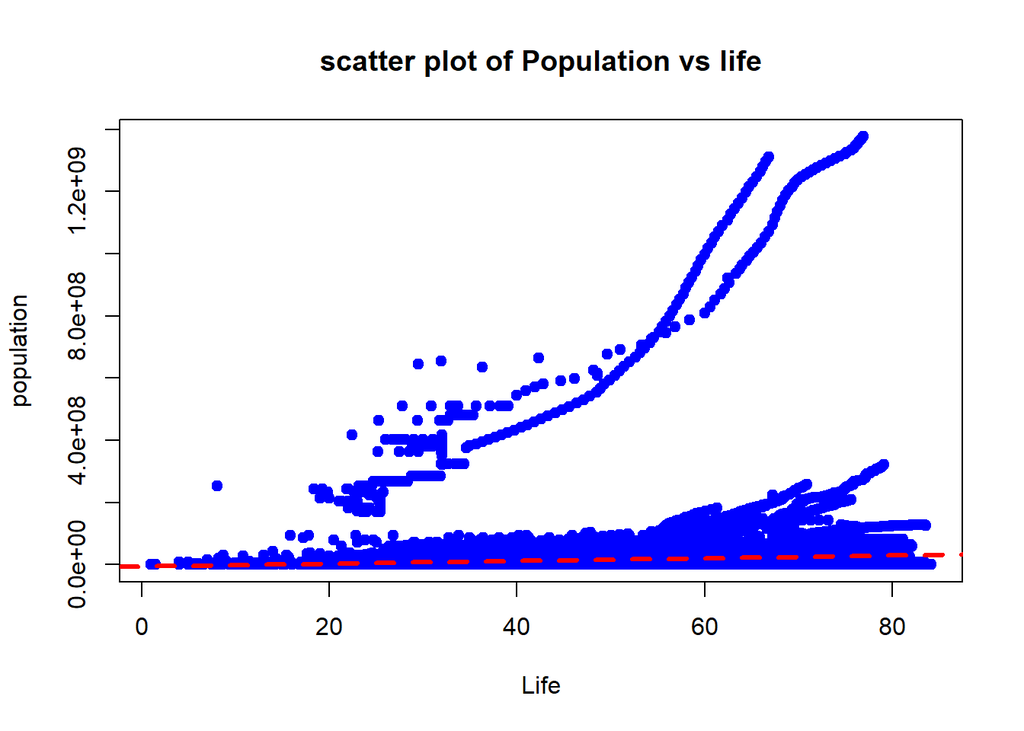

```r
plot(gap$population~gap$life,pch=19,col="blue",
     main='scatter plot of Population vs life',
     xlab="Life",
     ylab='population')
abline(lm(gap$population~gap$life),col="red",lty=2,lwd=3)
```

#### Income Vs Population

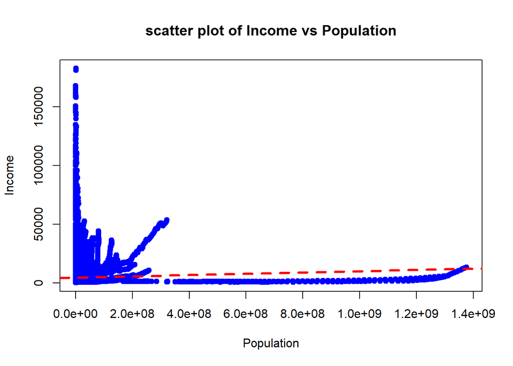

```r
plot(gap$income~gap$population,pch=19,col="blue",
     main='scatter plot of Income vs Population',
     xlab="Population",
     ylab='Income')
abline(lm(gap$income~gap$population),col="red",lty=2,lwd=3)
```

- scatter plot shows population and Income are not having any linear relationship _ Both of the attributes don’t have any relation

### Trend of income over life across regions

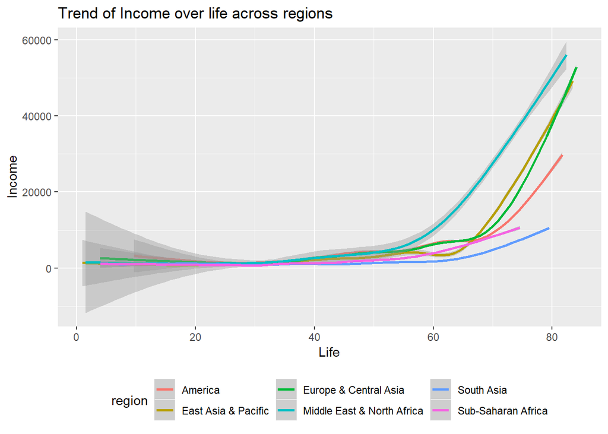

```r
ggplot(gap[complete.cases(gap), ])+
  geom_smooth(mapping=aes(x=life,y=income,col=region))+
  labs(title="Trend of Income over life across regions",x="Life", y = "Income")+
   theme(legend.position="bottom")
```

- Till age of 50 Income don’t have any impact over life, from Age of 50 Life expectancy increased with Income levels across all the regions

### Trend of population over life across all regions

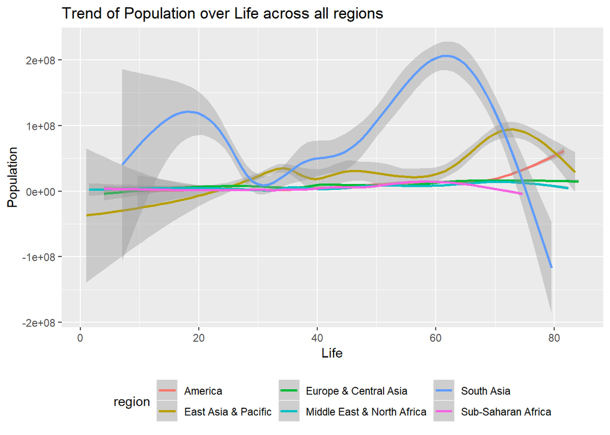

```r
ggplot(gap[complete.cases(gap), ])+
  geom_smooth(mapping=aes(x=life,y=population,col=region))+
  labs(title="Trend of Population over Life across all regions",x="Life", y = "Population")+
   theme(legend.position="bottom")
```

- Europe & central asia, subsahran africa, Middle East & North Africa, America don’t show any trend of popoulation over life
- South Asia has two high points and two low points, indicates distribution is binomial
- East Asia Pacific has data skewed toward right

### Trend of population over income across all regions

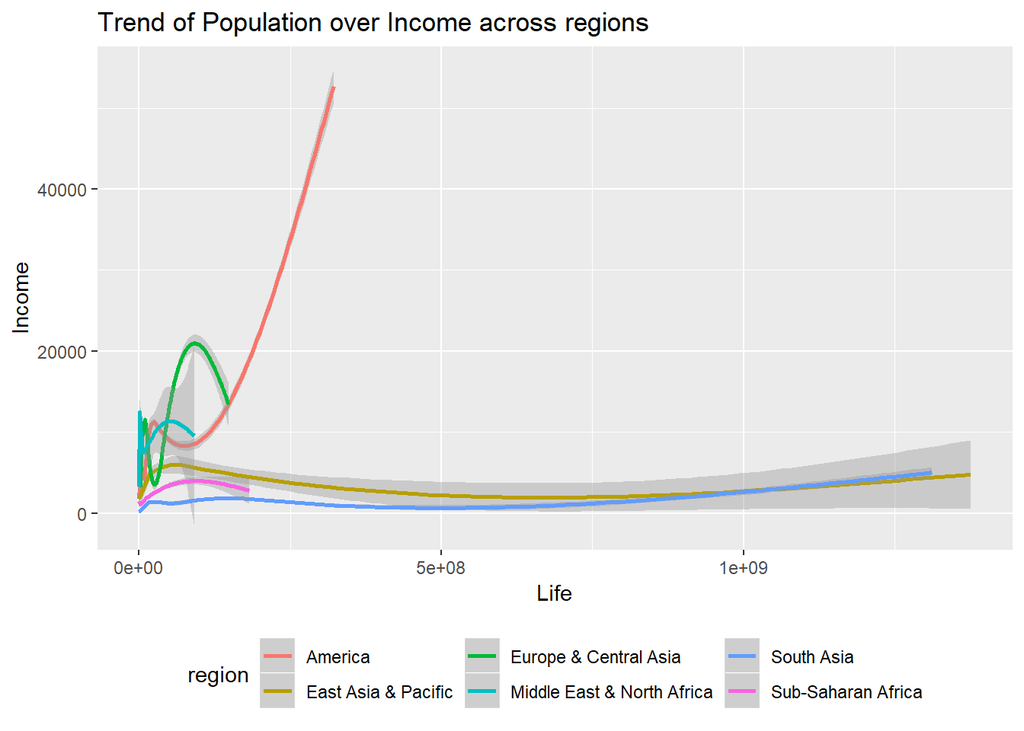

```r
ggplot(gap[complete.cases(gap), ])+
  geom_smooth(mapping=aes(x=population,y=income,col=region,size=life))+
  labs(title="Trend of Population over Income across regions",x="Life", y = "Income")+
  theme(legend.position="bottom")
```

- Trend of Income over population is not normal across all regions
- Income over population does not show substantial trend across regions

### Verify distribution of life

#### All regions

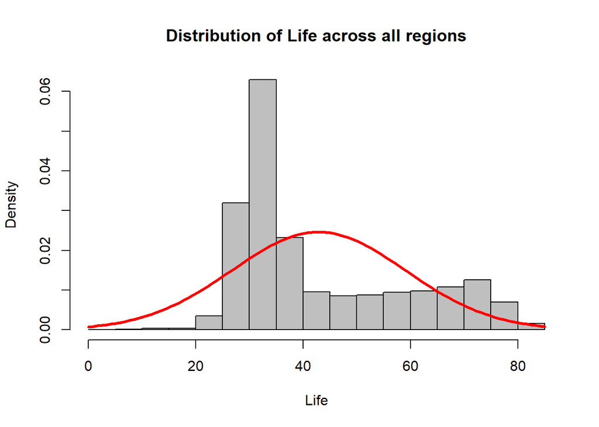

```r
hist(gap$life,
     col="grey75",
     main="Distribution of Life across all regions",
     xlab ="Life",
     prob= TRUE)
curve(dnorm(x,mean(gap$life),
            sd(gap$life)),
      add=TRUE,
      col="red",
      lwd=3)
```

- Life is not normally distributed across all ages
- it is skewed toward right
- No of countries before 40 is high compared to after 40

#### America

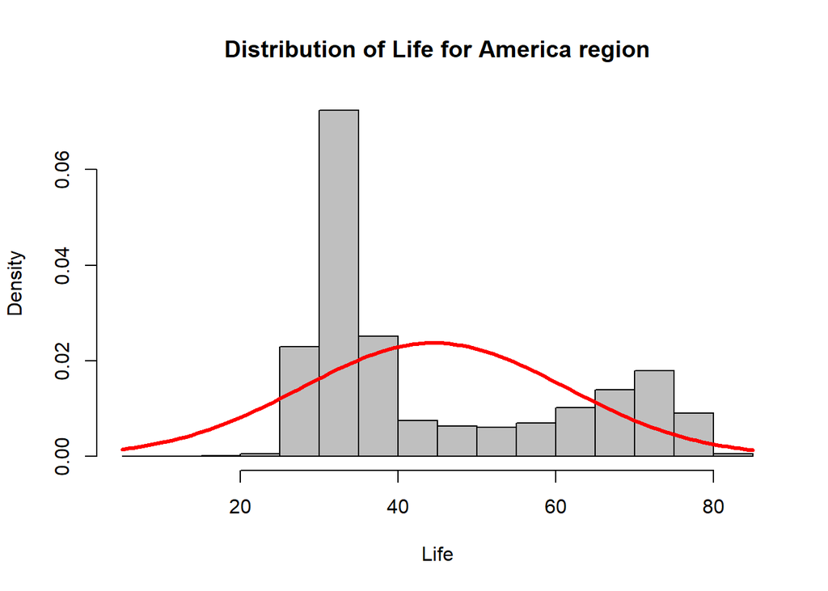

```r
hist(gap[gap$region=="America",]$life,
     col="grey75",
     main="Distribution of Life for America region",
     xlab ="Life",
     prob= TRUE)
curve(dnorm(x,mean(gap[gap$region=="America",]$life),
            sd(gap[gap$region=="America",]$life)),
      add=TRUE,
      col="red",
      lwd=3)
```

- Life for america is not normal it is binomial since theare are two high points

#### East Asia & Pacific

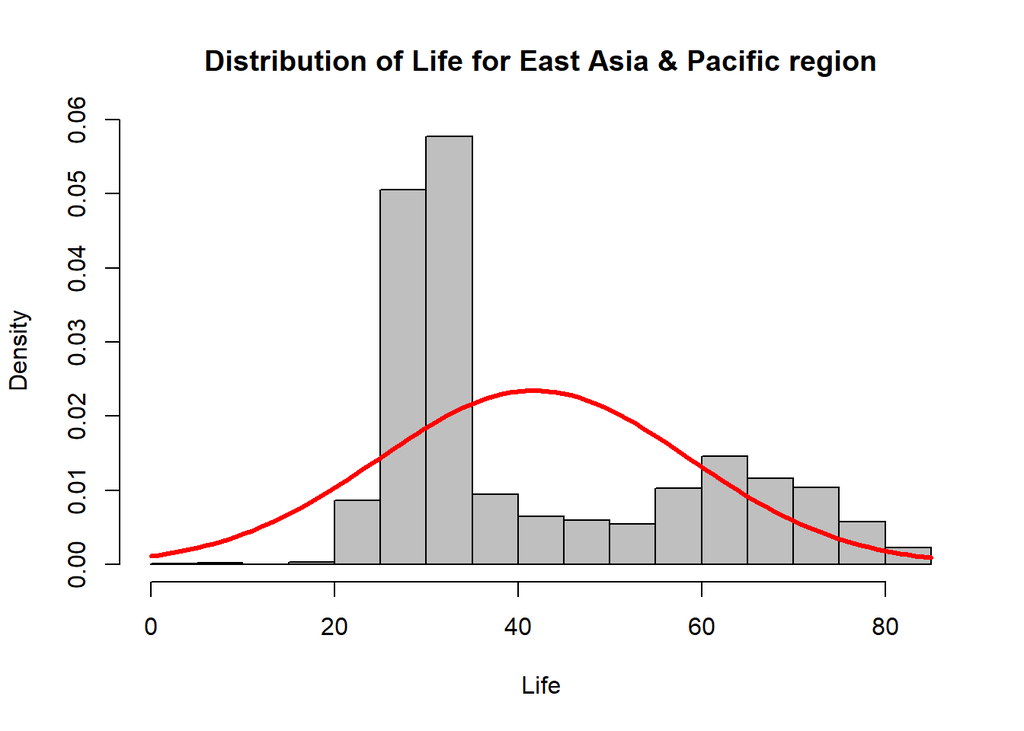

```r
hist(gap[gap$region=="East Asia & Pacific",]$life,
     col="grey75",
     main="Distribution of Life for East Asia & Pacific region",
     xlab ="Life",
     prob= TRUE)
curve(dnorm(x,mean(gap[gap$region=="East Asia & Pacific",]$life),
            sd(gap[gap$region=="East Asia & Pacific",]$life)),
      add=TRUE,
      col="red",
      lwd=3)
```

- Life for East Asia and pacific is not distributed normally
- Same as america region it has two highs

#### Europe & Central Asia

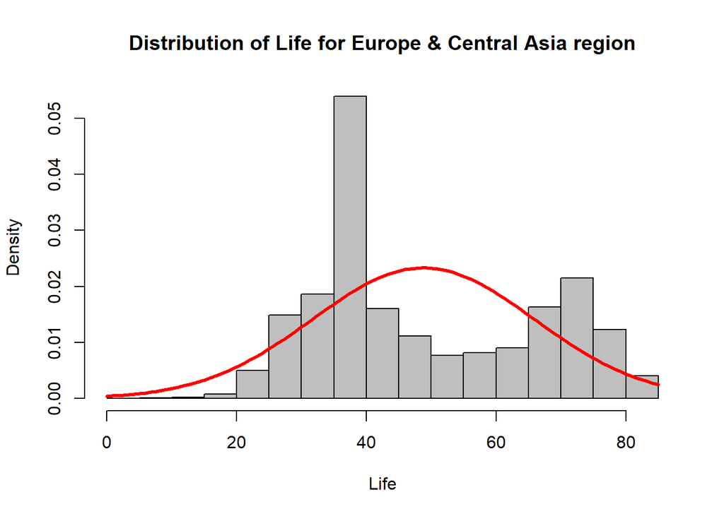

```r
hist(gap[gap$region=="Europe & Central Asia",]$life,
     col="grey75",
     main="Distribution of Life for Europe & Central Asia region",
     xlab ="Life",
     prob= TRUE)
curve(dnorm(x,mean(gap[gap$region=="Europe & Central Asia",]$life),
            sd(gap[gap$region=="Europe & Central Asia",]$life)),
      add=TRUE,
      col="red",
      lwd=3)
```

- Life for Europe and central Asia is not distributed normally
- Same as other regions it has two highs

#### Middle East & North Africa

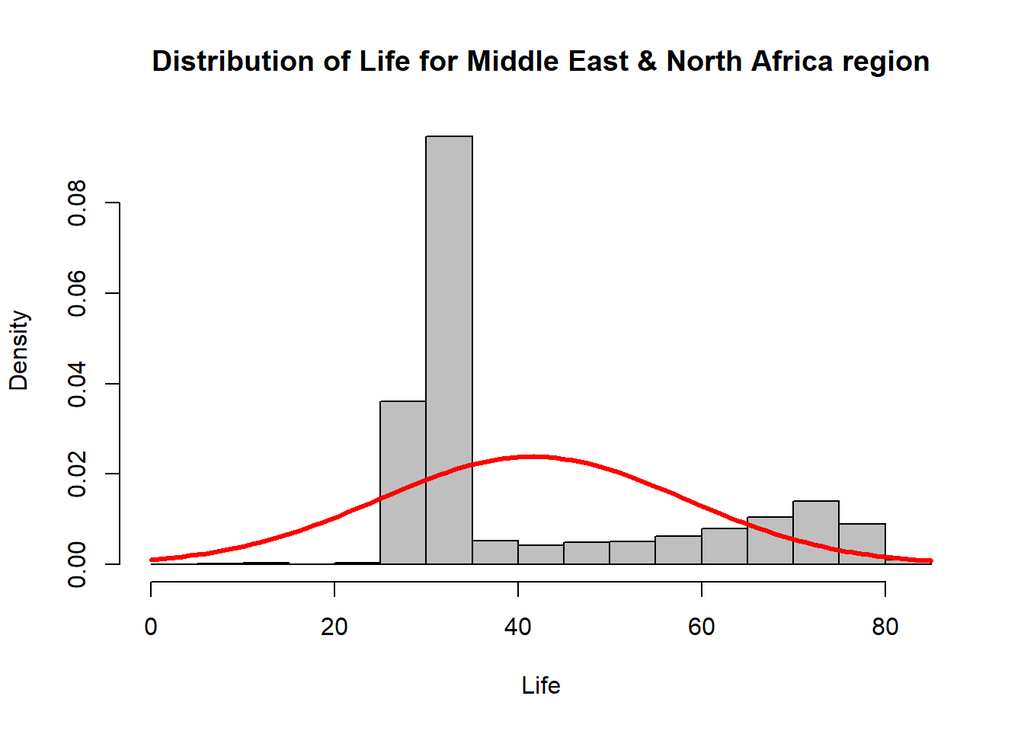

```r
hist(gap[gap$region=="Middle East & North Africa",]$life,
     col="grey75",
     main="Distribution of Life for Middle East & North Africa region",
     xlab ="Life",
     prob= TRUE)
curve(dnorm(x,mean(gap[gap$region=="Middle East & North Africa",]$life),
            sd(gap[gap$region=="Middle East & North Africa",]$life)),
      add=TRUE,
      col="red",
      lwd=3)
```

- Life for middle east & north africa is not distributed normally
- Same as other regions it has two highs

#### South Asia

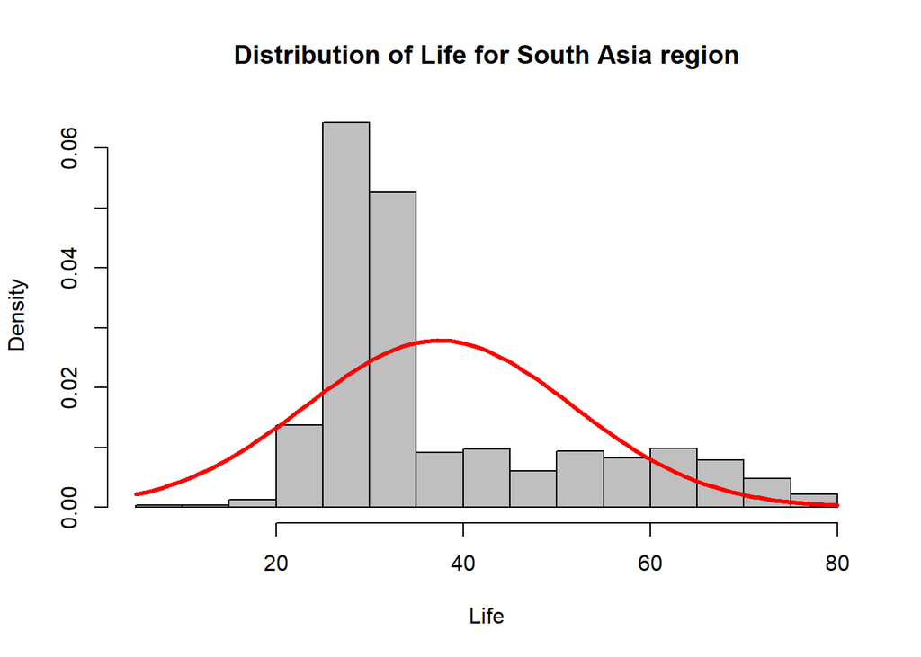

```r
hist(gap[gap$region=="South Asia",]$life,
     col="grey75",
     main="Distribution of Life for South Asia region",
     xlab ="Life",
     prob= TRUE)
curve(dnorm(x,mean(gap[gap$region=="South Asia",]$life),
            sd(gap[gap$region=="South Asia",]$life)),
      add=TRUE,
      col="red",
      lwd=3)
```

- Life for south Asia is not distributed normally
- Data before 40 exceeds normal curve

#### Sub-Saharan Africa

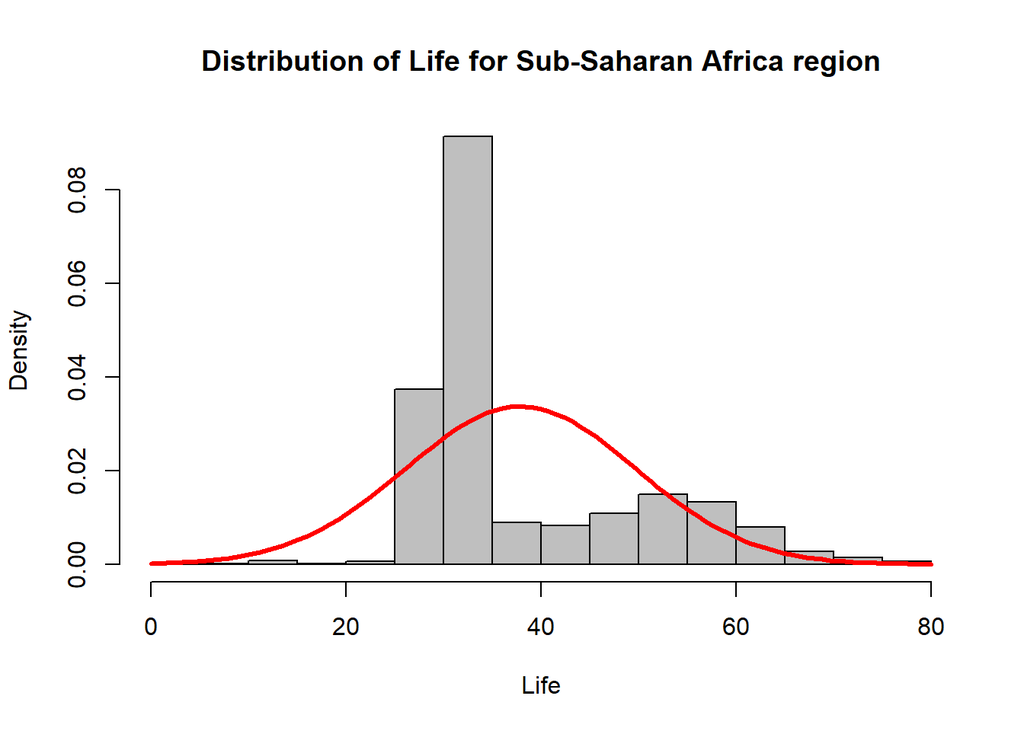

```r
hist(gap[gap$region=="Sub-Saharan Africa",]$life,
     col="grey75",
     main="Distribution of Life for Sub-Saharan Africa region",
     xlab ="Life",
     prob= TRUE)
curve(dnorm(x,mean(gap[gap$region=="Sub-Saharan Africa",]$life),
            sd(gap[gap$region=="Sub-Saharan Africa",]$life)),
      add=TRUE,
      col="red",
      lwd=3)
```

- Life for sub-saharan africa region is not distributed normally
- data below 30 is outside normal range.